# PRR Gruppenarbeit k-Fertig

Noah Recher, Logan Henchoz, Kevin Wartmann

Juni 2023

# 1 Datenbeschaffung

## 1.1 Datenbezug

## 1.2 Datenbeschreibung

## 1.3 Datenimport

### 1.3.1 Pakete laden

```r
packages <- c(
  "tidyverse", "plyr", "httr", "jsonlite", "timetk", "dplyr", "tidyr", "readxl", "lubridate"
)
easypackages::libraries(packages)
```

[output not shown]

### 1.3.2 Daten laden

#### 1.3.2.1 Import über REST-API

```r
# search <- function(search_params = NULL, start_date = NULL, end_date = NULL) {
#   url <- "http://46.231.204.49:80/search"
#
#   query_params <- search_params
#
#   if (!is.null(start_date) && !is.null(end_date)) {
#     query_params$start_date <- start_date
#     query_params$end_date <- end_date
#   }
#
#   response <- GET(url, query = query_params)
#
#   if (status_code(response) == 200) {
#     data <- content(response, "text")
#     json_obj <- fromJSON(data)
#     return(json_obj)
#   } else {
#     print("Error retrieving data!")
#   }
# }
#
# # Funktion aufrufen
# df <- search(
#   start_date = "2023-04-26",
#   end_date = "2023-06-04"
# )
```

#### 1.3.2.2 Import über CSV-Datei

```r
df <- read.csv("cde2.csv", sep=",")
```

## 1.4 Datenbereinigung

### 1.4.1 Daten umstrukturieren

```r
# Messwerte von einer Spalte auf eine Zeile transformieren
df <- df %>%
  pivot_wider(names_from=c(sensor_id,einheit_id),values_from = wert) %>%
  group_by(zeitstempel) %>%
  summarise_each(funs(mean=mean(., na.rm = TRUE)))
```

### 1.4.2 Benötigte Spalten selektieren und umbenennen

```r
# Benötigte Spalten selektieren
df <- df %>% select(c("zeitstempel", "experiment_id_mean","2_3_mean", "2_4_mean", "2_1_mean", "1_2_mean", "1_4_mean", "1_1_mean"))

# Spalten umbenennen
colnames(df) <- c("date_time", "experiment", "mc_distance", "mc_humidity", "mc_temperature", "pi_co2", "pi_humidity", "pi_temperature")
```

### 1.4.3 Datentypen anpassen

```r
str(df)
```

```
## tibble [528,790 × 8] (S3: tbl_df/tbl/data.frame)
##  $ date_time     : chr [1:528790] "2023-04-25 16:46:30" "2023-04-25 16:46:36" "2023-04-25 16:46:41" "2023-04-25 16:46:47" ...
##  $ experiment    : num [1:528790] 1 1 1 1 1 1 1 1 1 1 ...
##  $ mc_distance   : num [1:528790] 5.42 5.46 5.46 5.46 5.47 ...
##  $ mc_humidity   : num [1:528790] 51 51 51 51 51 51 52 52 53 53 ...
##  $ mc_temperature: num [1:528790] 15 15 15 15 15 15 15 15 15 15 ...
##  $ pi_co2        : num [1:528790] 522 522 524 524 525 ...
##  $ pi_humidity   : num [1:528790] 29 29 29 29 29 29 29 29 29 29 ...
##  $ pi_temperature: num [1:528790] 21 21 21 21 21 21 21 21 21 21 ...
```

```r
# Spalten korrekte Datentypen zuordnen
df$date_time <- df$date_time <- ymd_hms(df$date_time)
df <- df %>% mutate_at(c("experiment", "mc_humidity", "mc_temperature", "pi_humidity", "pi_temperature"), as.integer)

# Kategorien für co2-Werte erstellen
df$co2_grouped <- cut(df$pi_co2, breaks = seq(0,2000, by=50))

# Kategorien für Feuchtigkeitswerte erstellen
df$humidity_grouped <- cut(df$pi_humidity, breaks = seq(0,100, by=5))
```

### 1.4.4 Externe Datenquelle anfügen

```r
# Externe Daten importieren
df_extern <- read_excel("externe_datenquelle.xlsx")

# Konvertiere in gleiches Zeitformat
df_extern$time <- ymd_hms(df_extern$time)

# Runde die Zeitstempel auf die nächste Stunde auf oder ab, basierend auf den Minuten
df$rounded_hour <- ifelse(minute(df$date_time) > 30, ceiling_date(df$date_time, unit = "hour"), floor_date(df$date_time, unit = "hour"))

# Konvertiere die Spalte "rounded_hour" in den gleichen Datentyp wie die Spalte "time" in df_extern
df$rounded_hour <- as_datetime(df$rounded_hour)

# Aussentemperatur anhand der Zeit einfügen
df <- left_join(df, df_extern %>% select(time, temp), by = c("rounded_hour" = "time")) %>% select(-rounded_hour)
```

### 1.4.5 Zeitintervall definieren

```r
df <- df %>%
  filter(date_time >= as.Date("2023-04-26 00:00:00") & date_time <= as.Date("2023-06-04 00:00:00"))
```

### 1.4.6 Fenster Status bestimmen

```r
df$mc_distance <- df$mc_distance > 10
```

### 1.4.7 Daten nach Experiment aufteilen

```r
df_exp_1 <- df %>% filter(experiment == 1) %>% select(!experiment)
df_exp_2 <- df %>% filter(experiment == 2) %>% select(!experiment)
```

### 1.4.8 Ausreisser untersuchen

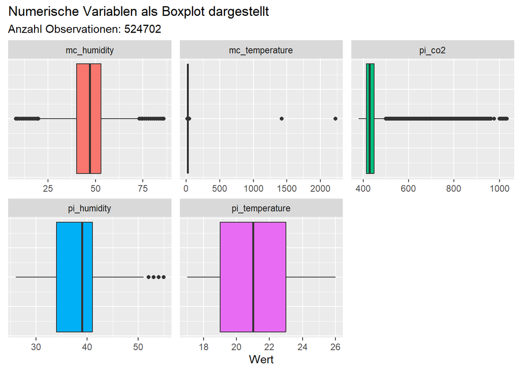

```r
df %>%
  gather(key = "variable", value = "value", c("mc_humidity", "mc_temperature", "pi_co2", "pi_humidity", "pi_temperature")) %>%
  ggplot(aes(x = value, fill = variable)) +
  geom_boxplot(show.legend = FALSE) +
  facet_wrap(~ variable, scales = "free") +
  theme(axis.text.y=element_blank(),
        axis.ticks.y=element_blank()) +
  labs(title = 'Numerische Variablen als Boxplot dargestellt',
       subtitle = paste('Anzahl Observationen:', nrow(df)),
       x = 'Wert')
```

```r
df %>%
  arrange(desc(mc_temperature)) %>%
  slice(1:3)
```

| date_time | experiment | mc_distance | mc_humidity | mc_temperature | pi_co2 | pi_humidity | pi_temperature | co2_grouped | humidity_grouped | temp |
| --- | --- | --- | --- | --- | --- | --- | --- | --- | --- | --- |
| 2023-05-08 15:46:24 | 2 | FALSE | 57 | 2224 | 689.7011 | 44 | 23 | (650,700] | (40,45] | 17.9 |
| 2023-05-23 14:57:23 | 2 | FALSE | 58 | 1424 | 722.9536 | 48 | 21 | (700,750] | (45,50] | 20.1 |
| 2023-05-04 12:46:24 | 1 | TRUE | 14 | 47 | 524.3291 | 29 | 26 | (500,550] | (25,30] | 21.1 |

Bei der Temperatur Messung vom Micro-Controller gab es zwei Temperatur Messwerte von über 1000 Grad. Wir löschen diese Einträge.

```r
df <- df %>% subset(mc_temperature < 1000)
```

# 2 Explorative Datenanalyse

## 2.1 Summarische Statistik

```r
summary(df)
```

```
##    date_time                        experiment    mc_distance
##  Min.   :2023-04-26 00:00:01.00   Min.   :1.000   Mode :logical
##  1st Qu.:2023-05-05 01:19:43.75   1st Qu.:1.000   FALSE:517649
##  Median :2023-05-14 03:21:11.00   Median :2.000   TRUE :7051
##  Mean   :2023-05-14 03:31:27.82   Mean   :1.546
##  3rd Qu.:2023-05-23 05:06:31.25   3rd Qu.:2.000
##  Max.   :2023-06-01 08:45:53.00   Max.   :2.000
##
##   mc_humidity    mc_temperature      pi_co2        pi_humidity
##  Min.   : 8.00   Min.   :14.00   Min.   : 380.0   Min.   :26.00
##  1st Qu.:40.00   1st Qu.:21.00   1st Qu.: 414.0   1st Qu.:34.00
##  Median :47.00   Median :22.00   Median : 428.7   Median :39.00
##  Mean   :46.48   Mean   :22.28   Mean   : 447.9   Mean   :37.78
##  3rd Qu.:53.00   3rd Qu.:23.00   3rd Qu.: 448.6   3rd Qu.:41.00
##  Max.   :86.00   Max.   :47.00   Max.   :1032.7   Max.   :55.00
##
##  pi_temperature     co2_grouped     humidity_grouped      temp
##  Min.   :17.00   (400,450]:366806   (40,45]:163678   Min.   : 4.50
##  1st Qu.:19.00   (450,500]: 68357   (35,40]:154589   1st Qu.:11.90
##  Median :21.00   (350,400]: 32035   (30,35]:116924   Median :14.00
##  Mean   :21.02   (500,550]: 15828   (25,30]: 60658   Mean   :14.67
##  3rd Qu.:23.00   (550,600]: 13360   (45,50]: 28120   3rd Qu.:17.30
##  Max.   :26.00   (600,650]: 12722   (50,55]:   731   Max.   :25.80
##                  (Other)  : 15592   (Other):     0
```

## 2.2 Verteilungen visualisieren

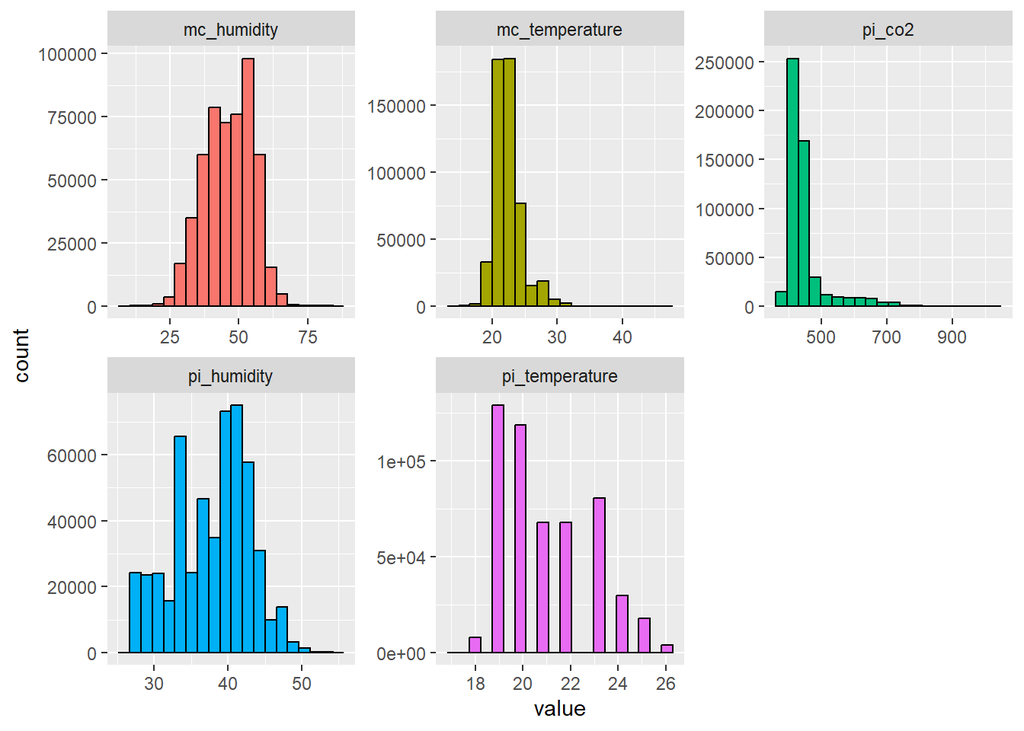

```r
df %>%
  pivot_longer(names_to = "variable", values_to = "value", cols = c("mc_humidity", "mc_temperature", "pi_co2", "pi_humidity", "pi_temperature")) %>%
  ggplot(aes(value, fill = variable)) +
  geom_histogram(bins = 20, color = "black", show.legend = FALSE ) +
  facet_wrap(~variable, scales = "free")
```

## Zeitreihen visualisieren

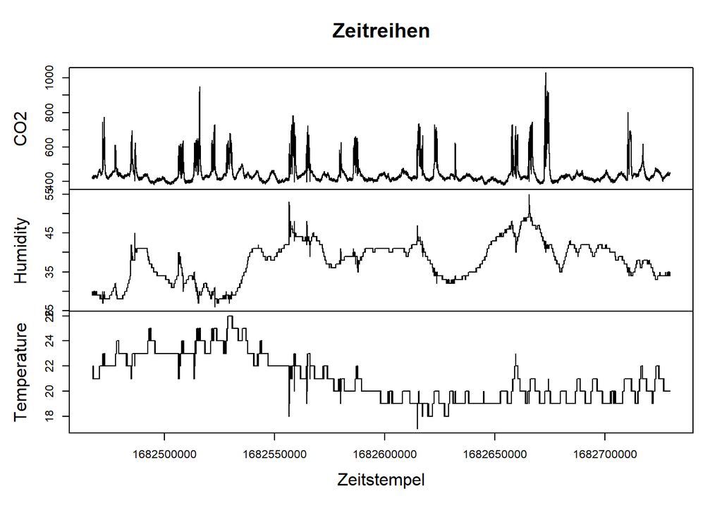

```r
# Erstellen eines Zeitreihenobjekts für jeden Wert
CO2 <- ts(df$pi_co2, start = min(df$date_time), frequency = 2)
Humidity <- ts(df$pi_humidity, start = min(df$date_time), frequency = 2)
Temperature <- ts(df$pi_temperature, start = min(df$date_time), frequency = 2)

# Zusammenfügen der Zeitreihen in eine Matrix
ts_matrix <- cbind(CO2, Humidity, Temperature)

# Visualisierung der Zeitreihen
plot(ts_matrix, main = "Zeitreihen", xlab = "Zeitstempel", ylab = "Wert")
```

```r
ggsave("./Bilder/Abbildung_1.png", width = 12, height = 8, dpi = 300, bg = "white")
```

# 3 Fragestellungen

## 3.1 1. Fragestellung

### 3.1.1 Lüftvorgänge filtern

```r
# Bestimmen, wann der Fenster Status auf offen ändert und denn Lüftvorgang startet
oeffnungs_index <- which(diff(df$mc_distance) == TRUE) + 1
oeffnungs_zeitpunkt <- df$date_time[oeffnungs_index]

# Bestimmen, wann der Fenster Status auf geschlossen ändert und der Lüftvorgang beendet wird
schliessungs_index <- which(diff(df$mc_distance) == -1) + 1
schliessungs_zeitpunkt <- df$date_time[schliessungs_index]

# Neuen Datensatz zur Befüllung initialisieren
df_lueftintervalle <- data.frame()

# In einer Schleife die Lüftungsintervalle herausfiltern
for (i in 1:length(oeffnungs_index)) {

  # Zeitpunkt setzen, wann das Fenster geöffnet wurde
  fenster_oeffnung <- oeffnungs_zeitpunkt[i]

  # Zeitintervall setzen abhängig davon wie lange die Lüftung dauert oder maximal 10 Minuten
  end_zeitpunkt <-  min(schliessungs_zeitpunkt[i], oeffnungs_zeitpunkt[i] + 600)

  # Relevante Daten auslesen und modifizieren
  lueftintervall <- df %>%
    filter(df$date_time >= fenster_oeffnung & df$date_time <= end_zeitpunkt) %>%  # Observationen des Lüftungsintervalls aggregieren
    mutate(lueftung_id = i) %>%  # Observationen dem Lüftintervall zuordnen
    mutate(initial_co2_grouped = first(co2_grouped),  # Start co2-Wert anfügen
           initial_humidity_grouped = first(humidity_grouped),  # Start Humidity anfügen
           seconds_past = as.numeric(difftime(date_time, fenster_oeffnung, units = "secs")))  # Sekunden seit Beginn des Lüftungsvorgangs berechnen

  df_lueftintervalle <- rbind(df_lueftintervalle, lueftintervall)  # Intervall zum DataFrame hinzufügen
}

print(df_lueftintervalle)
```

```
## # A tibble: 4,349 × 15
##    date_time           experiment mc_distance mc_humidity mc_temperature pi_co2
##    <dttm>                   <int> <lgl>             <int>          <int>  <dbl>
##  1 2023-04-26 15:23:18          1 TRUE                 31             24   720.
##  2 2023-04-26 15:23:28          1 TRUE                 28             24   745.
##  3 2023-04-26 15:23:39          1 TRUE                 27             23   742.
##  4 2023-04-26 15:23:49          1 TRUE                 28             23   731.
##  5 2023-04-26 15:24:00          1 TRUE                 28             23   716.
##  6 2023-04-26 15:24:11          1 TRUE                 28             23   703.
##  7 2023-04-26 15:24:21          1 TRUE                 28             22   697.
##  8 2023-04-26 15:24:32          1 TRUE                 29             22   692.
##  9 2023-04-26 15:24:38          1 TRUE                 29             22   691.
## 10 2023-04-26 15:24:42          1 TRUE                 29             22   689.
## # ℹ 4,339 more rows
## # ℹ 9 more variables: pi_humidity <int>, pi_temperature <int>,
## #   co2_grouped <fct>, humidity_grouped <fct>, temp <dbl>, lueftung_id <int>,
## #   initial_co2_grouped <fct>, initial_humidity_grouped <fct>,
## #   seconds_past <dbl>
```

### 3.1.2 Ungültige Lüftvorgänge entfernen

In Lüftdurchgang Nummer 66 waren mehr als eine Person im Zimmer weswegen dieser nicht repräsentativ ist und wir ihn entfernen.

```r
df_lueftintervalle <- df_lueftintervalle %>% filter(lueftung_id != 66)
```

### 3.1.3 Lüftvorgänge visualisieren

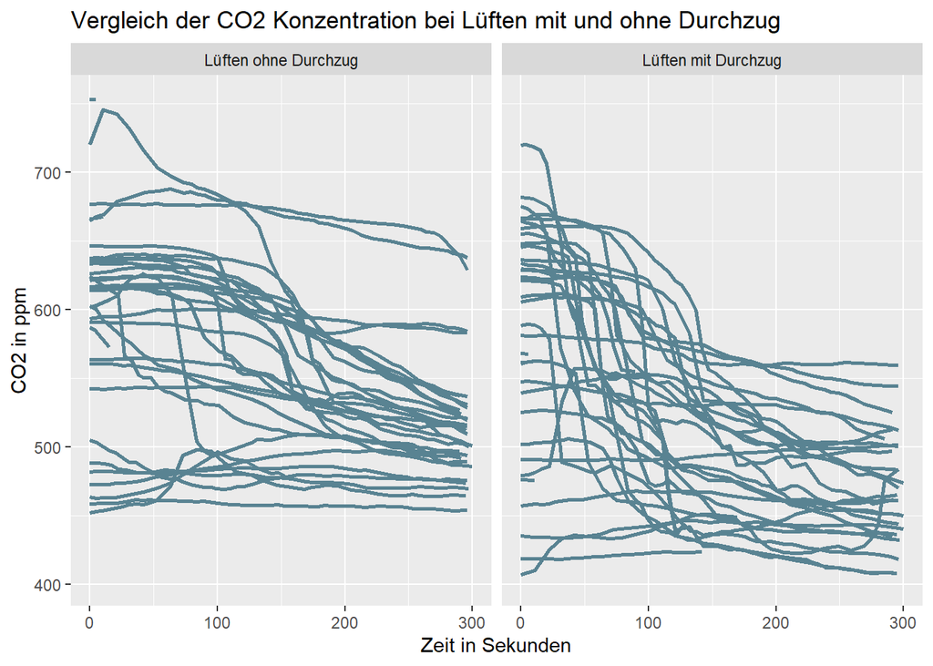

```r
df_lueftintervalle %>%
  ggplot(aes(x = seconds_past, y = pi_co2, group = lueftung_id)) +
  geom_line(size = 1, color = "#598392") +
  xlim(c(0,300)) +
  facet_wrap(~ experiment, labeller = labeller(experiment = c("1" = "Lüften ohne Durchzug", "2" = "Lüften mit Durchzug"))) +
  labs(title = "Vergleich der CO2 Konzentration bei Lüften mit und ohne Durchzug", x = "Zeit in Sekunden", y = "CO2 in ppm")
```

```r
ggsave("./Bilder/Abbildung_2.png", width = 12, height = 8, dpi = 300, bg = "white")
```

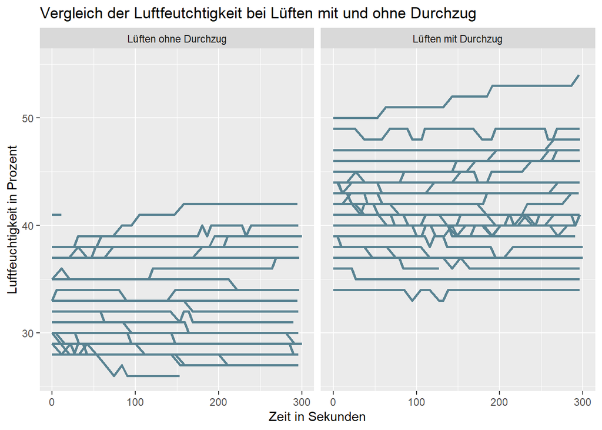

```r
df_lueftintervalle %>%
  ggplot(aes(x = seconds_past, y = pi_humidity, group = lueftung_id)) +
  geom_line(size = 1, color = "#598392") +
  xlim(c(0,300)) +
  facet_wrap(~ experiment, labeller = labeller(experiment = c("1" = "Lüften ohne Durchzug", "2" = "Lüften mit Durchzug"))) +
  labs(title = "Vergleich der Luftfeutchtigkeit bei Lüften mit und ohne Durchzug", x = "Zeit in Sekunden", y = "Luftfeuchtigkeit in Prozent")
```

```r
ggsave("./Bilder/Abbildung_3.png", width = 12, height = 8, dpi = 300, bg = "white")
```

### 3.1.4 Lüftdurchgänge gruppieren

Nun komprimieren wir die Daten etwas um die Grafik überschaubarer zu machen. Hierfür gruppieren wir nicht mehr nach lueftungs_id sondern nach initial_co2_grouped also dem initialen co2-Wert. Ausserdem berechnen wir den co2-Durchschnitt pro Minute.

```r
# Gruppierung für CO2
df_lueftintervalle_grouped_co2 <- df_lueftintervalle %>%
  group_by(experiment, lueftung_id, initial_co2_grouped) %>%  # Daten Nach Experiment und Lüftintervall gruppieren
  summarise_by_time(date_time, .by = "minute", .type = "floor", co2_mean = mean(pi_co2)) %>%  # Durchschnittlicher co2-Wert pro Minute berechnen
  dplyr::mutate(minutes_past = as.numeric(difftime(date_time, first(date_time), units = "mins"))) %>%  # Minuten seid Beginn der Lüftung berechnen
  group_by(experiment, initial_co2_grouped, minutes_past) %>%  # Nach Experiment und Initalem co2-Wert und Minute gruppieren
  dplyr::summarise(co2_mean = mean(co2_mean), .groups="keep")  # Durchschnittlichen co2-Wert berechnen

# Gruppierung für Luftfeuchtigkeit
df_lueftintervalle_grouped_humidity <- df_lueftintervalle %>%
  group_by(experiment, lueftung_id, initial_humidity_grouped) %>%  # Daten Nach Experiment und Lüftintervall gruppieren
  summarise_by_time(date_time, .by = "minute", .type = "floor", humidity_mean = mean(pi_humidity)) %>%  # Durchschnittlicher co2-Wert pro Minute berechnen
  dplyr::mutate(minutes_past = as.numeric(difftime(date_time, first(date_time), units = "mins"))) %>%  # Minuten seid Beginn der Lüftung berechnen
  group_by(experiment, initial_humidity_grouped, minutes_past) %>%  # Nach Experiment und Initalem co2-Wert und Minute gruppieren
  dplyr::summarise(humidity_mean = mean(humidity_mean), .groups="keep")  # Durchschnittlichen co2-Wert berechnen
```

### 3.1.5 Gruppierte Lüftdurchgänge visualisieren

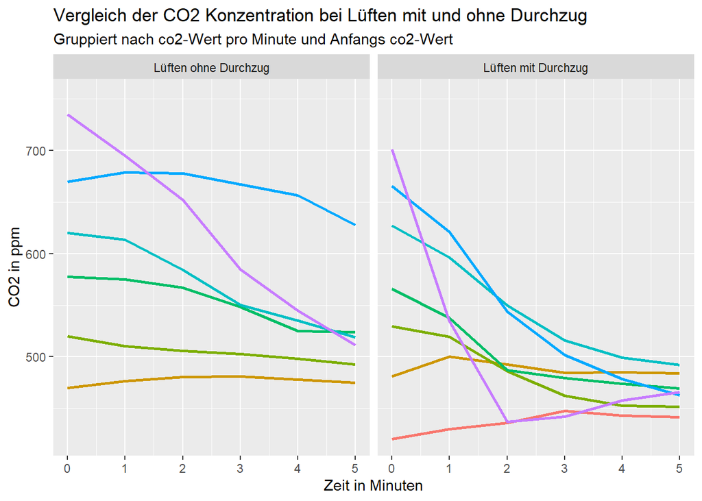

```r
df_lueftintervalle_grouped_co2 %>%
  ggplot(aes(x = minutes_past, y = co2_mean, group = initial_co2_grouped, color = initial_co2_grouped)) +
  geom_line(size = 1, show.legend = FALSE) +
  xlim(c(0,5)) +
  facet_wrap(~ experiment, labeller = labeller(experiment = c("1" = "Lüften ohne Durchzug", "2" = "Lüften mit Durchzug"))) +
  labs(title = "Vergleich der CO2 Konzentration bei Lüften mit und ohne Durchzug", subtitle = "Gruppiert nach co2-Wert pro Minute und Anfangs co2-Wert", x = "Zeit in Minuten", y = "CO2 in ppm")
```

```r
ggsave("./Bilder/Abbildung_4.png", width = 12, height = 8, dpi = 300, bg = "white")
```

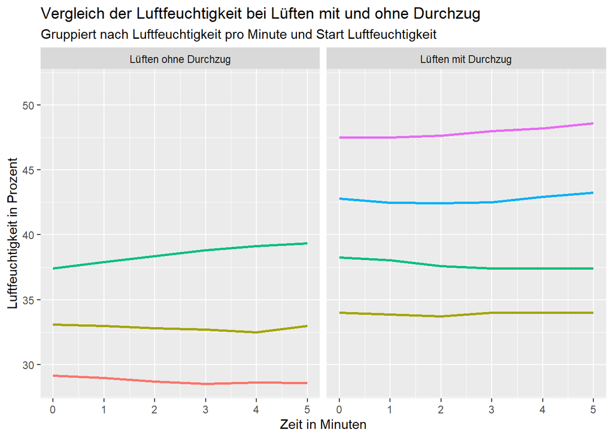

```r
df_lueftintervalle_grouped_humidity %>%
  ggplot(aes(x = minutes_past, y = humidity_mean, group = initial_humidity_grouped, color = initial_humidity_grouped)) +
  geom_line(size = 1, show.legend = FALSE) +
  xlim(c(0,5)) +
  facet_wrap(~ experiment, labeller = labeller(experiment = c("1" = "Lüften ohne Durchzug", "2" = "Lüften mit Durchzug"))) +
  labs(title = "Vergleich der Luftfeuchtigkeit bei Lüften mit und ohne Durchzug", subtitle = "Gruppiert nach Luftfeuchtigkeit pro Minute und Start Luftfeuchtigkeit", x = "Zeit in Minuten", y = "Luftfeuchtigkeit in Prozent")
```

```r
ggsave("./Bilder/Abbildung_5.png", width = 12, height = 8, dpi = 300, bg = "white")
```

## 3.2 2. Fragestellung

Da wir in der ersten Fragestellung zeigen konnten, dass Lüften mit Durchzug effizienter ist, werden wir uns für diese Fragestellung auf Lüftungen aus Experiment 2 also Lüften mit Durchzug beschränken.

Um ein repräsentatives Resultat zu erzielen, entfernen wir Lüftdurchgänge, bei welchen der co2-Wert Innen beim öffnen des Fensters besser war als draussen. Also alle Durchgänge, bei welchen der Start co2-Wert tiefer war als der End co2-Wert. Ausserdem wählen wir nur Durchgänge, welche länger als 3 Minuten dauerten.

```r
filtered_intervals <- df_lueftintervalle %>%
  group_by(lueftung_id) %>%
  filter(first(pi_co2) >= last(pi_co2) & first(pi_co2) >= 500 & last(seconds_past >= 180) & experiment == 2) %>%
  ungroup()
```

Wir teilen ausserdem in verschiedene Klassen ein, bezüglich dem Unterschied der Innen- und Aussentemperatur.

```r
filtered_intervals <- filtered_intervals %>%
  group_by(lueftung_id) %>%
  mutate(temp_diff_group = cut(abs(pi_temperature - temp), breaks = seq(0,20, by=2)))
```

Nun erstellen wir zwei Funktionen, welche sowohl für die Temperatur und das CO2 die optimale Lüftungsdauer annähern.

find_opt_co2:

Um die optimale Lüftungsdauer für den CO2-Wert zu finden, wollten wir den Punkt annähern, bei welchem der Raum den CO2-Wert von Aussen angenommen hat, sich dieser also nur noch leicht bis gar nicht verändert. Hierfür haben wir den minimalen CO2-Wert gesucht, und im Intervall von minimaler CO2-Wert +- 10 den ersten Zeitpunkt gewählt, bei welchem sich der Messwert im Intervall befindet.

find_opt_temperature:

Um die optimale Lüftungsdauer für die Temperatur anzunähern, haben wir den letzten Zeitpunkt gewählt, bei welchem die Temperatur nur um ein Grad von der Innentemperatur als der Anfangstemperatur der Lüftung abweicht.

```r
find_opt_co2 <- function(data, lueftungszeit) {
  min_value <- min(data)  # Minimalen Messwert finden
  target_range <- c(min_value - 10, min_value + 10)  # Intervall definieren

  # Index des ersten Messwerts im Intervall finden
  nearest_index <- min(which(data >= target_range[1] & data <= target_range[2]))

  # Den Wert anhand des Index zurückgeben
  nearest_value <- lueftungszeit[nearest_index]

  return(nearest_value)
}

find_opt_temperature <- function(temperatur, lueftungszeit) {

  # Letzter Wert suchen, bei dem die Temperaturdifferenz kleiner als 2 ist
  start_temperatur <- temperatur[1]  # Starttemperatur ist der erste Wert
  last_temperatur_index <- max(which(abs(start_temperatur - temperatur) <= 1))
  letzter_wert_temperatur <- lueftungszeit[last_temperatur_index]

  return(letzter_wert_temperatur)
}

# Gruppieren nach Lüftungs-ID und Anwendung der Funktion auf jedes Lüftungsintervall
ergebnis <- filtered_intervals %>%
  filter(experiment == 2) %>%
  group_by(lueftung_id) %>%
  dplyr::summarise(t_co2_konstant = find_opt_co2(pi_co2, seconds_past), t_temperatur_konstant = find_opt_temperature(pi_temperature, seconds_past), temp_diff_group = first(temp_diff_group))

print(ergebnis)
```

```
## # A tibble: 23 × 4
##    lueftung_id t_co2_konstant t_temperatur_konstant temp_diff_group
##          <int>          <dbl>                 <dbl> <fct>
##  1          36            386                   196 (6,8]
##  2          38            413                   530 (4,6]
##  3          39            381                   397 (4,6]
##  4          40            302                   311 (2,4]
##  5          42            343                   280 (4,6]
##  6          43            260                   498 (2,4]
##  7          45            417                   575 (6,8]
##  8          46            263                   285 (6,8]
##  9          47            323                   413 (6,8]
## 10          48            280                   300 (8,10]
## # ℹ 13 more rows
```

Hier die Resultate unserer Funktionen, welche die optimale Lüftungsdauer eruieren.

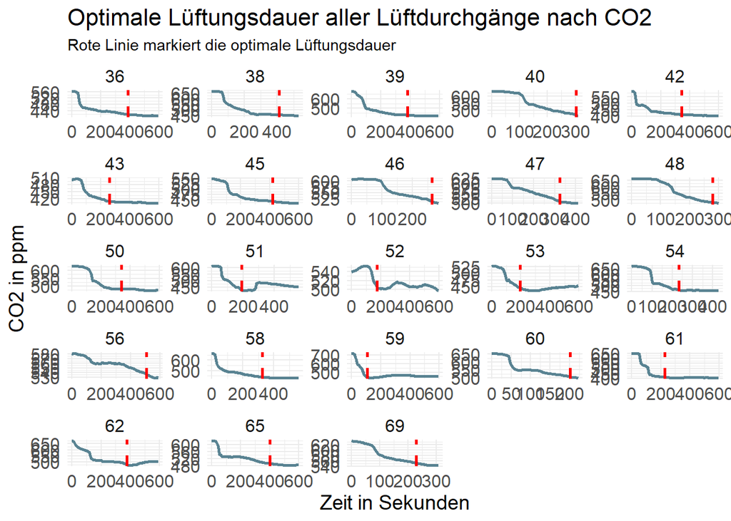

```r
filtered_intervals %>% filter(experiment == 2) %>%
  ggplot(aes(x = seconds_past, y = pi_co2, group = lueftung_id)) +
  geom_line(size = 1, color = "#598392") +
  geom_vline(data = ergebnis, aes(xintercept = t_co2_konstant), color = "red", linetype = "dashed", size = 1) +
  facet_wrap(~ lueftung_id, scales = "free") +
  theme_minimal() +
  labs(title = "Optimale Lüftungsdauer aller Lüftdurchgänge nach CO2", subtitle = "Rote Linie markiert die optimale Lüftungsdauer", x = "Zeit in Sekunden", y = "CO2 in ppm") +
  theme(plot.title = element_text(size = 16),
        axis.title = element_text(size = 14),
        axis.text = element_text(size = 12),
        strip.text = element_text(size = 12))
```

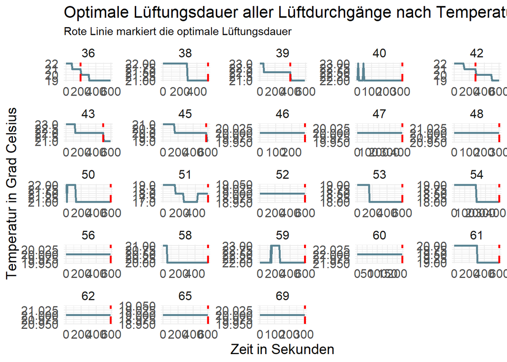

```r
ggsave("./Bilder/Optimum_Lüftungsdauer_CO2.png", width = 12, height = 8, dpi = 300, bg = "white")

filtered_intervals %>% filter(experiment == 2) %>%
  ggplot(aes(x = seconds_past, y = pi_temperature, group = lueftung_id)) +
  geom_line(size = 1, color = "#598392") +
  geom_vline(data = ergebnis, aes(xintercept = t_temperatur_konstant), color = "red", linetype = "dashed", size = 1) +
  facet_wrap(~ lueftung_id, scales = "free") +
  theme_minimal() +
  labs(title = "Optimale Lüftungsdauer aller Lüftdurchgänge nach Temperatur", subtitle = "Rote Linie markiert die optimale Lüftungsdauer", x = "Zeit in Sekunden", y = "Temperatur in Grad Celsius") +
  theme(plot.title = element_text(size = 16),
        axis.title = element_text(size = 14),
        axis.text = element_text(size = 12),
        strip.text = element_text(size = 12))
```

```r
ggsave("./Bilder/Optimum_Lüftungsdauer_Temperatur.png", width = 12, height = 8, dpi = 300, bg = "white")
```

Wir berechnen nun die optimale Lüftungsdauer, wenn man die Energieeffizienz nicht berücksichtigt.

```r
print(paste("Die optimale Lüftungsdauer nur auf CO2 bezogen ist: ", round(mean(ergebnis$t_co2_konstant) / 60, 2), " Minuten"))
```

```
## [1] "Die optimale Lüftungsdauer nur auf CO2 bezogen ist:  4.98  Minuten"
```

Wir beziehen nun noch den Faktor Energieeffizienz ein, indem wir denn Schnitt zwischen der optimalen Lüftungszeit für das CO2 und der Temperatur nehmen. Sollte die optimale Lüftungszeit der Temperatur nach der des CO2 liegen, wird die optimale Lüftungsdauer des CO2 verwendet, da die Tempertatur ja immernoch auf Raumtempertatur ist.

```r
df_energieeffizient <- ergebnis %>%
  group_by(temp_diff_group) %>%
  mutate(t_energieeffizient = ifelse(t_co2_konstant <= t_temperatur_konstant, t_co2_konstant, (t_co2_konstant + t_temperatur_konstant)/2))

print(paste("Die optimale Lüftungsdauer inkl. Energieeffizienz ist: ", round(mean(df_energieeffizient$t_energieeffizient) / 60, 2), " Minuten"))
```

```
## [1] "Die optimale Lüftungsdauer inkl. Energieeffizienz ist:  4.89  Minuten"
```

```r
df_energieeffizient_grouped <- df_energieeffizient %>% group_by(temp_diff_group) %>% dplyr::summarise(mean_per_group = mean(t_energieeffizient), n = n())
```

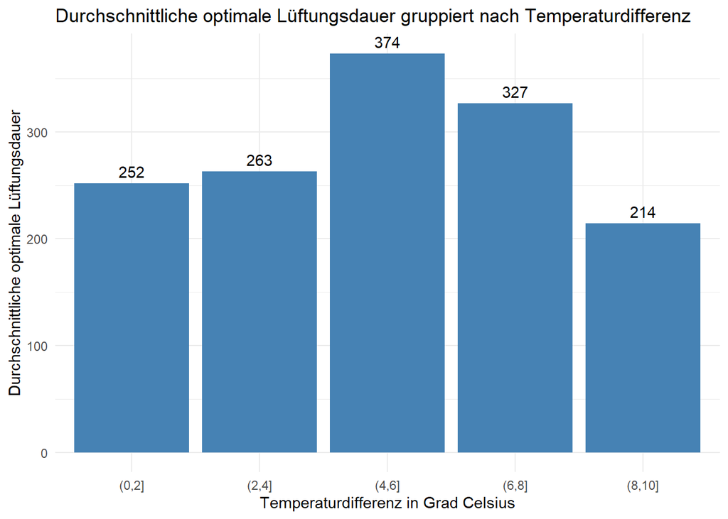

```r
df_energieeffizient_grouped %>%
  ggplot(aes(x = temp_diff_group, y = mean_per_group)) +
  geom_bar(stat = "identity", fill = "steelblue") +
  labs(x = "Temperaturdifferenz in Grad Celsius",
       y = "Durchschnittliche optimale Lüftungsdauer") +
  ggtitle("Durchschnittliche optimale Lüftungsdauer gruppiert nach Temperaturdifferenz") +
  theme_minimal() +
  geom_text(aes(label = round(mean_per_group, 0)), vjust = -0.5)
```

```r
ggsave("./Bilder/Abbildung_6.png", width = 12, height = 8, dpi = 300, bg = "white")
```

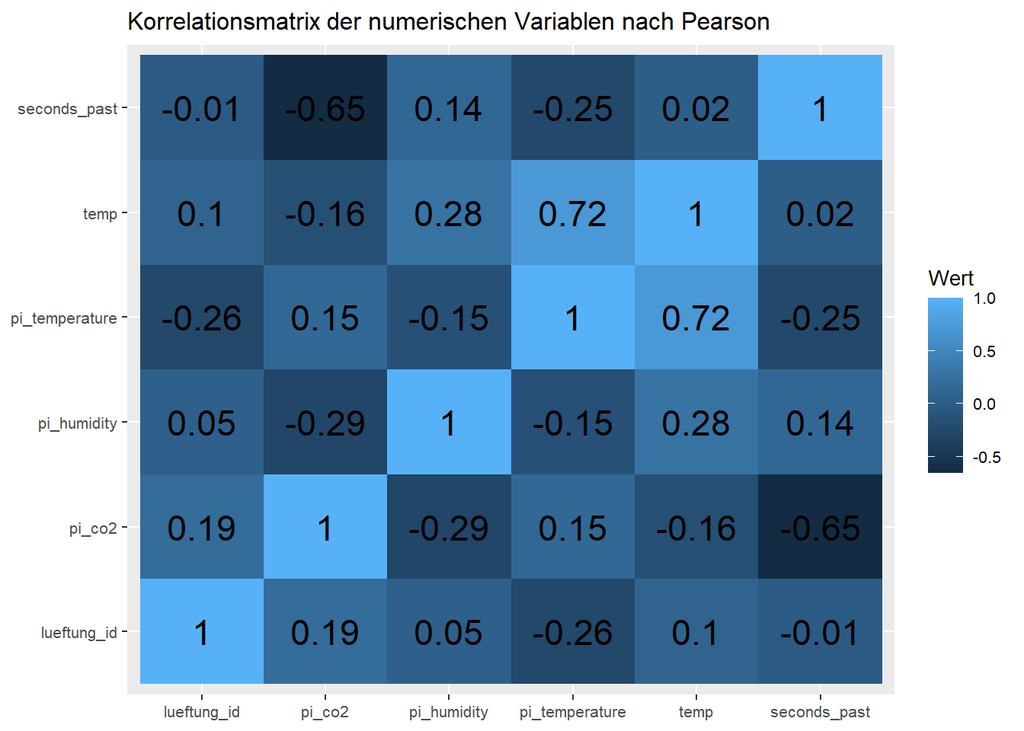

```r
filtered_intervals %>%
  select(lueftung_id, pi_co2, pi_humidity, pi_temperature, temp, seconds_past) %>%
  cor(method = "pearson") %>%
  reshape2::melt() %>%
  ggplot(aes(x = Var1, y = Var2, fill = value)) +
  geom_tile() +
  geom_text(aes(label = round(value, 2)), size = 6) +
  theme(
    axis.title.x = element_blank(),
    axis.title.y = element_blank(),
    text = element_text(size = 10)
  ) +
  labs(
    title = "Korrelationsmatrix der numerischen Variablen nach Pearson",
    fill = "Wert"
  )
```

```r
ggsave("./Bilder/Abbildung_7.png", width = 12, height = 8, dpi = 300, bg = "white")
```

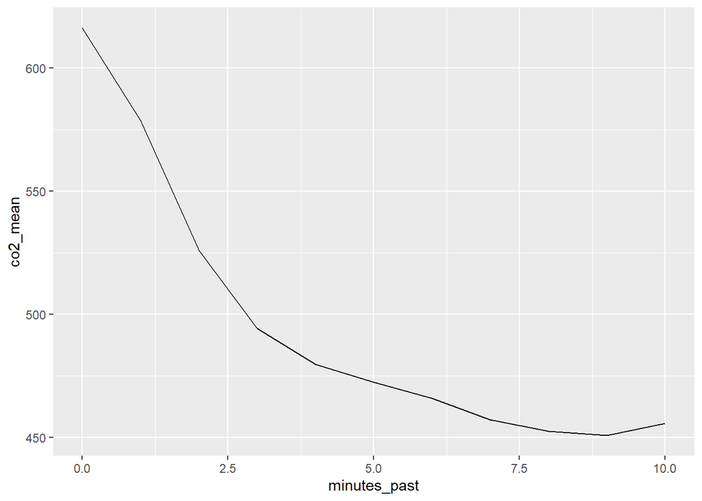

```r
filtered_intervals_mean_per_min <- filtered_intervals %>%
  group_by(lueftung_id) %>%  # Daten Nach Experiment und Lüftintervall gruppieren
  summarise_by_time(date_time, .by = "minute", .type = "floor", co2_mean = mean(pi_co2)) %>%  # Durchschnittlicher co2-Wert pro Minute berechnen
  dplyr::mutate(minutes_past = as.numeric(difftime(date_time, first(date_time), units = "mins"))) %>%
  group_by(minutes_past) %>%
  dplyr::summarise(co2_mean = mean(co2_mean))

filtered_intervals_mean_per_min %>% ggplot(aes(x=minutes_past,y=co2_mean)) + geom_line()
```

```r
ggsave("./Bilder/Abbildung_8.png", width = 12, height = 8, dpi = 300, bg = "white")
```

## 3.3 3. Fragestellung

Sehen wir eine Änderung der Luftqualität, sprich in der Luftfeuchtigkeit oder beim CO2-Wert, wenn wir drei Pflanzen in unser Büro stellen ?

Wir vergleichen hier die Versuche 1 und 2, wobei der erste Versuch ohne Pflanzen im Büro und der zweite Versuch mit drei verschiedenen Pflanzen durchgeführt wurde. Es handelt sich um eine Zamioculcas zamiifolia, eine Schefflera arboricola und einen Ficus elastica.

```r
#Neues Dataframe um unabhängig zu Arbeiten, entferne nicht benötigte Spalte
df_frage_3 <- df %>% select(-c("co2_grouped"))



#Datentyp anpassen
df_frage_3$experiment <- as.factor(df_frage_3$experiment)



#Wichentage aus Datum erzeugen für spätere Visualisierungen
df_frage_3 <- df_frage_3 %>% mutate(Wochentag=  wday(df_frage_3$date_time, label = TRUE))




#Funktion um jeden Wechsel zwischen Fenster offen und geschlossen zu detektieren
add_window_change_count <- function(data) {
  data$luefungsnr <- cumsum(c(0, diff(data$mc_distance) != 0))
  return(data)
}



df_frage_3 <- add_window_change_count(df_frage_3)
```

In einem ersten Versuch haben wir mit einer einfachen Methode die Tagesmittelwerte von CO2 und Feuchte für Tage mit und ohne Pflanzen verglichen. Unser Ziel war es, bereits mit diesen Messungen einen möglichen Unterschied festzustellen und Hinweise auf den Einfluss der Pflanzen zu finden.

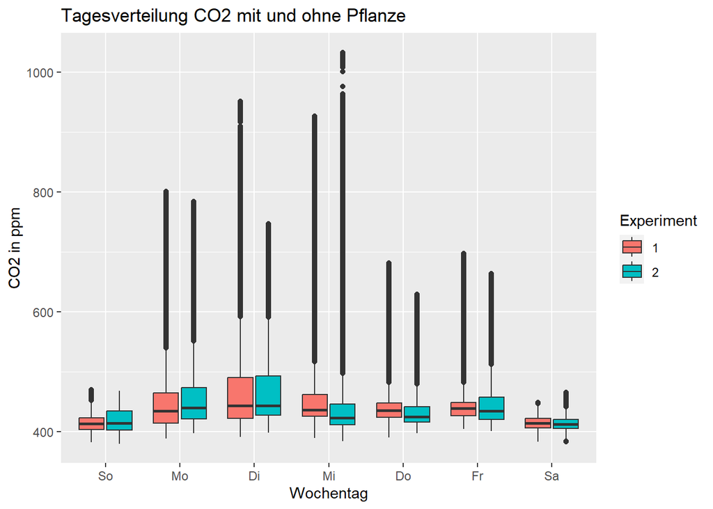

```r
ggplot(df_frage_3, aes(x = Wochentag, y = pi_co2, fill = experiment ))+
  geom_boxplot() +
  labs(fill = "Experiment", title = "Tagesverteilung CO2 mit und ohne Pflanze", y= "CO2 in ppm")
```

Der Vergleich der CO2-Werte bringt keine Erkenntnisse. Weder der Median der Daten noch die Verteilung scheinen sich signifikant zu ändern, wenn man den ganzen Tag zusammenfasst.

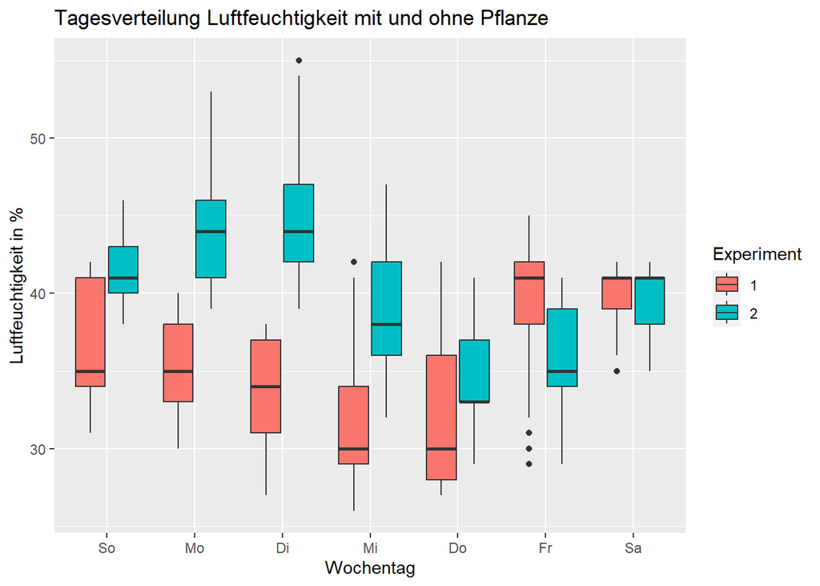

```r
ggplot(df_frage_3, aes(x = Wochentag, y = pi_humidity  , fill = experiment ))+
  geom_boxplot() +
  labs(fill = "Experiment", title = "Tagesverteilung Luftfeuchtigkeit mit und ohne Pflanze", y= "Luftfeuchtigkeit in %")
```

Bei der Luftfeuchtigkeit zeigen die Tage Sonntag, Montag und Dienstag eine Tendenz zu höherer Luftfeuchtigkeit, Freitag und Samstag widerlegen diese Behauptung. Man kann aber auch die Verteilung der Luftfeuchtigkeit vergleichen, d.h. die Länge der Boxplots. Aber auch diese sind bei beiden Versuchen vergleichbar. Die beiden Tagesvergleiche lassen keine Rückschlüsse auf den Einfluss der Pflanzen zu.

```r
# Bestimmen, wann der Fenster Status auf geschlossen ändert und der Lüftvorgang beendet wird
schliessungs_index <- which(diff(df$mc_distance) == -1) + 1
schliessungs_zeitpunkt <- df$date_time[schliessungs_index]



# Neuen Datensatz zur Befüllung initialisieren
df_closed_30 <- data.frame()



# In einer Schleife die Lüftungsintervalle herausfiltern
for (i in 1:length(schliessungs_index)) {

  # Zeitpunkt setzen, wann das Fenster geöffnet wurde
  fenster_schliessungs <- schliessungs_zeitpunkt[i]

  # Zeitintervall setzen abhängig davon wie lange die Lüftung dauert
  end_zeitpunkt <-  schliessungs_zeitpunkt[i] + 1800

  # Relevante Daten auslesen und modifizieren
  steigintervall <- df %>%
    filter(df$date_time >= fenster_schliessungs & df$date_time <= end_zeitpunkt) %>%  # Observationen des Lüftungsintervalls aggregieren
    group_by(experiment) %>%
    mutate(lueftung_id = i) %>%  # Observationen dem Lüftintervall zuordnen
    mutate(initial_co2_grouped = first(co2_grouped),  # Start ppm-Wert anfügen
           seconds_past = as.numeric(difftime(date_time, fenster_schliessungs, units = "secs")))  # Sekunden seit Beginn des Lüftungsvorgangs berechnen

  df_closed_30 <- rbind(df_closed_30, steigintervall)  # Intervall zum DataFrame hinzufügen
}
#Experiment für Visualiesierung als Faktor wandeln
df_closed_30$experiment <- as.factor(df_closed_30$experiment)
```

Im zweiten Experiment untersuchen wir den Einfluss der Pflanzen nach dem Lüften. Da wir im Büro jede Stunde lüften, vergleichen wir die Luftfeuchtigkeit und den CO2-Wert nach einer halben Stunde. Die Hypothese ist, dass die Pflanzen den Anstieg des CO2 bremsen und die Luftfeuchtigkeit konstant halten.

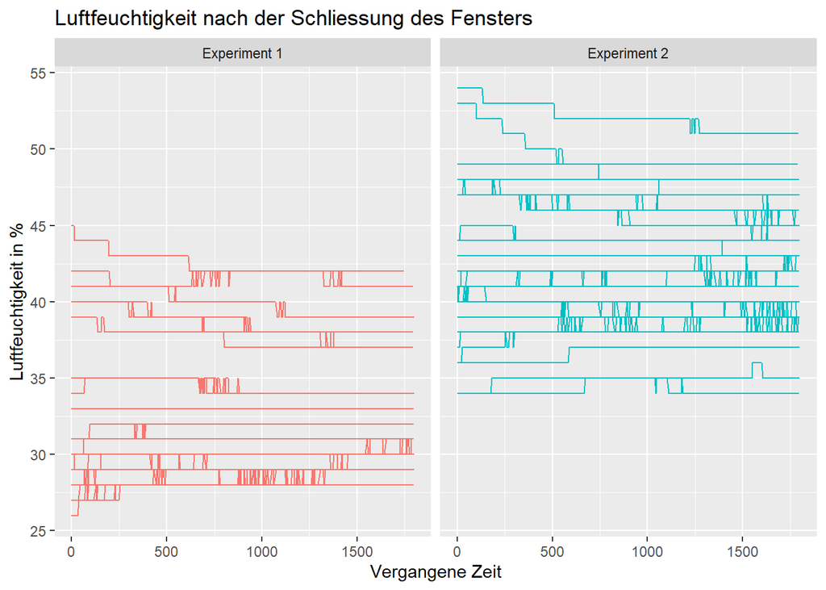

```r
#Messungen die weniger lang als 30Minuten dauern werden sie entfernt
df_closed_30 %>% group_by(experiment, lueftung_id) %>% filter(!any(mc_distance == TRUE)) %>%
  #Visualisierung der Luftfeuchtigkeit nach dem Lüften, pro Experiment
  ggplot(aes(x = seconds_past, y = pi_humidity, group = lueftung_id, color = experiment))+
  geom_line(show.legend = FALSE)+
  facet_wrap(~experiment, labeller = labeller(experiment = c("1" = "Experiment 1", "2" = "Experiment 2")))+
  labs(title = "Luftfeuchtigkeit nach der Schliessung des Fensters", y = "Luftfeuchtigkeit in %", x = "Vergangene Zeit")
```

Bei der Luftfeuchtigkeit ist eine deutliche Veränderung zu erkennen. Im Allgemeinen ist die Luftfeuchtigkeit mit Pflanze ca. 10% höher als im Versuch ohne Pflanzen.

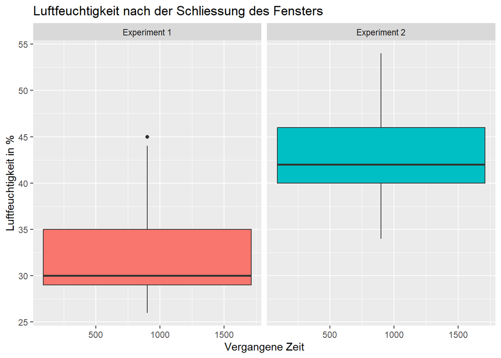

```r
#Messungen die weniger lang als 30Minuten dauern werden sie entfernt
df_closed_30 %>% group_by(experiment, lueftung_id) %>% filter(!any(mc_distance == TRUE)) %>%
  #Boxplot der Luftfeuchtigkeit nach dem Lüften, pro Experiment
  ggplot(aes(x = seconds_past, y = pi_humidity, fill = experiment))+
  geom_boxplot(show.legend = FALSE)+
  facet_wrap(~experiment, labeller = labeller(experiment = c("1" = "Experiment 1", "2" = "Experiment 2")))+
  labs(title = "Luftfeuchtigkeit nach der Schliessung des Fensters", y = "Luftfeuchtigkeit in %", x = "Vergangene Zeit")
```

Wir veranschaulichen diese Visualisierung etwas genauer mit einem Boxplot und sehen, dass die Streuung der Daten in etwa gleich ist. Allerdings ist der Median bei den Pflanzen um ca. 13% höher. Dies deutet auf eine Veränderung bei den Pflanzen hin.

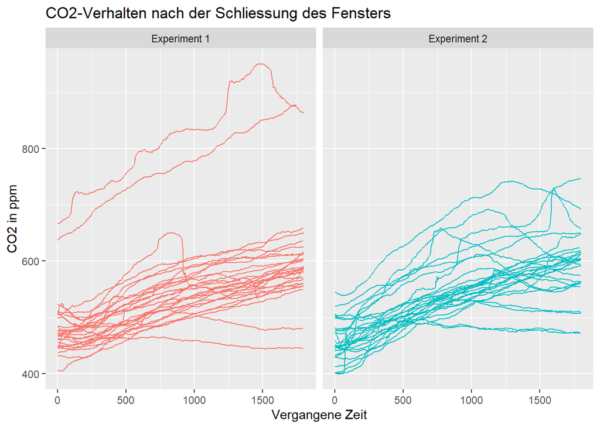

```r
#Messungen die weniger lang als 30Minuten dauern werden sie entfernt
df_closed_30 %>% group_by(experiment, lueftung_id) %>%
  filter(last(pi_co2) > first(pi_co2) & !any(mc_distance == TRUE)) %>%
  #Visualisierung des CO2-Wert nach dem Lüften, pro Experiment
  ggplot(aes(x = seconds_past, y = pi_co2, group = lueftung_id, color = experiment))+
  geom_line(show.legend = FALSE)+
  facet_wrap(~experiment, labeller = labeller(experiment = c("1" = "Experiment 1", "2" = "Experiment 2")))+
  labs(title = "CO2-Verhalten nach der Schliessung des Fensters", y = "CO2 in ppm", x = "Vergangene Zeit")
```

Hingegen bei dem Vergleich der CO2-Werten nach 30 Minuten sind bis auf zwei Ausreisser keine Einfluss der Pflanzen erkennt.

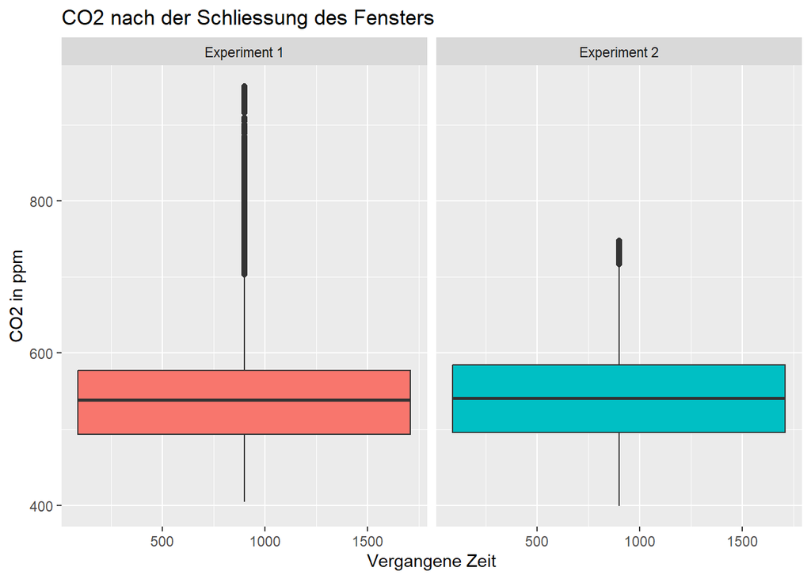

```r
#Messungen die weniger lang als 30Minuten dauern werden sie entfernt
df_closed_30 %>% group_by(experiment, lueftung_id) %>% filter(last(pi_co2) > first(pi_co2) & !any(mc_distance == TRUE)) %>% #Boxplot des CO2-Wert nach dem Lüften, pro Experiment
  ggplot(aes(x = seconds_past, y = pi_co2, fill = experiment))+
  geom_boxplot(show.legend = FALSE)+
  facet_wrap(~experiment, labeller = labeller(experiment = c("1" = "Experiment 1", "2" = "Experiment 2")))+
  labs(title = "CO2 nach der Schliessung des Fensters", y = "CO2 in ppm", x = "Vergangene Zeit")
```

Diese Aussage wird auch durch die Analyse der Boxplots bestätigt: Die Streuung der Daten und der Median der Daten sind fast identisch.

```r
#Wochenende-Datensatz erstellt aus den Wochentage Samstag und Sonntag
df_weekend <- df_frage_3 %>% filter(Wochentag == "Sa" | Wochentag == "So")
#Vergangene Zeit pro Wochenende als Variable hinzugefügt
hours_past <- df_weekend %>% group_by(luefungsnr) %>% dplyr::summarise(hours_past = as.numeric(difftime(date_time, first(date_time), units = "hours")))
hours_past <- hours_past$hours_past
#Vereinenen mit Weekend-Datensatz
df_weekend <- cbind(df_weekend, hours_past)
df_weekend$luefungsnr <- as.factor(df_weekend$luefungsnr)
#Neue Spalte, mit voller Stunde für Spätere Visualisierungen
df_weekend <- df_weekend %>% mutate(Stunde = hour(date_time))
```